# 01 City Code Formation-And Overview of City-levle Githubu Users

# Country Level Github Users

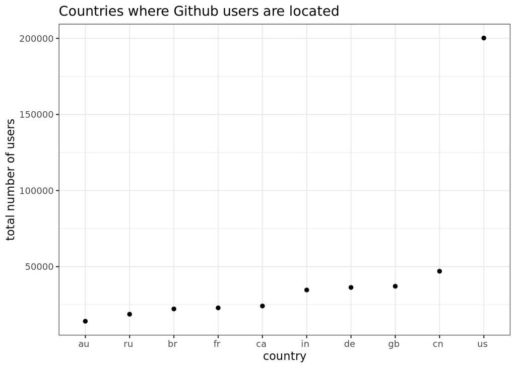

# City code formation

We exclude users who did not provide either country code or city information. (0.7724119% missing), which leaves us 487814 samples in the dataset. Note that country code is extracted from country, city, loaction, and longitude and latitude. Country code is missing if the user did not provide any of these information. Since we are interested in users at the city level, if we are missing city information, we could not extract a unique city.

We formed city code in the following steps:

First, we want to differentiate cities from different countries. We form a new variable "city_code", which is a concactinated form of country code and city. Since there could be multiples cities with the same name in different countries, "city_code" can be used to differentiate cities from from different countries.

Next, we want to differentiate cities within a country. Although we have state variable, but we decide no to use this variable due to the inaccurate report. We decide to use longitude and latitude to differentiate cities in different areas in a country. However, longtitude and latitude could vary from a small digit even though they indicate one city. We decide to group cities together if their long & lat deviate within a sum of 2 degrees.

The final "city_code" is a concactinated form of: -country code (generated) -city -latitude (round to a whole number) -longitude (round to a whole number)

# Clean citycode

```r
ls_cleancity <- cleancity(users_gh)
```

# City Level Github Users

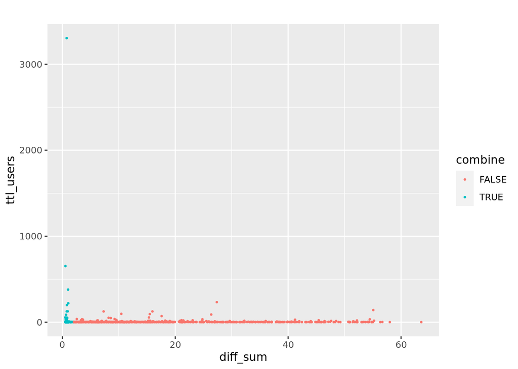

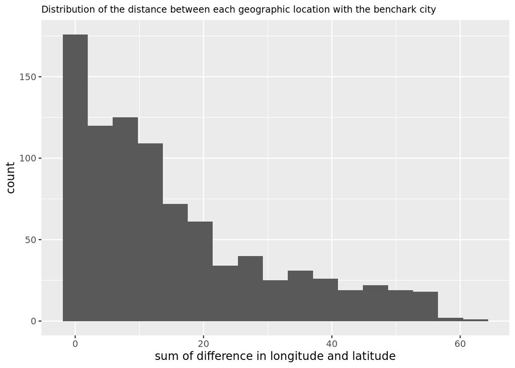

```
##
## FALSE  TRUE
##   723   177
```

### clean citycode visualization

[figure not shown]

```r
city_clean_final <- ls_cleancity$clean_df

city_clean_final_top <- city_clean_final%>%
   top_n(n= 10, wt = ttl_users)

city_clean_final_top$city <- factor(city_clean_final_top$city, levels = city_clean_final_top$city[order(city_clean_final_top$ttl_users)])


ggplot(city_clean_final_top, aes(x = city, y = ttl_users)) +
  geom_point()  +
  aes(colour = country_code)+
  theme(legend.position = "right") +
  labs(title = "Cities where Github users are located", x = "city", y = "total number of users") +
  theme_bw() +
  theme(axis.text.x = element_text(angle = 90, vjust = 0.5, hjust=1))
```

```r
# sf
#create shape file
gh_suer_sf <- st_as_sf(city_clean_final, coords = c("user_lat", "user_long"))
summary(gh_suer_sf)
```

```
##  combine         city_code           ttl_users       user_lat_round
##  Mode:logical   Length:1338        Min.   :    1.0   Min.   :-35.00
##  TRUE:169       Class :character   1st Qu.:    1.0   1st Qu.: 35.00
##  NA's:1169      Mode  :character   Median :    3.0   Median : 40.00
##                                    Mean   :  123.7   Mean   : 36.49
##                                    3rd Qu.:   12.0   3rd Qu.: 42.00
##                                    Max.   :15927.0   Max.   : 69.00
##  user_long_round   country_code           city              geometry
##  Min.   :-149.50   Length:1338        Length:1338        POINT  :1338
##  1st Qu.: -93.00   Class :character   Class :character   epsg:NA:   0
##  Median : -83.00   Mode  :character   Mode  :character
##  Mean   : -70.44
##  3rd Qu.: -73.00
##  Max.   : 153.00
```

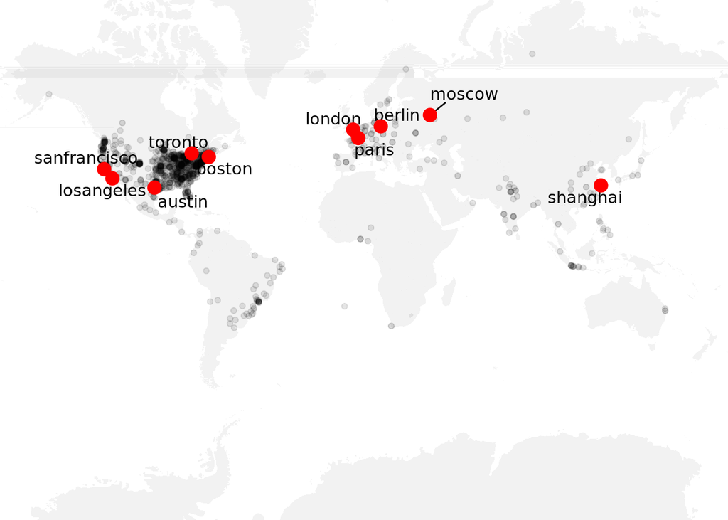

```r
world_map <- map_data("world")

library(ggrepel)
library(plotly)

#static map
ggplot() +
  geom_polygon(data = world_map, aes(x=long, y = lat, group = group), fill="grey", alpha=0.2) +
  geom_point( data= city_clean_final, aes(x=user_long, y=user_lat, alpha=ttl_users)) +
  geom_text_repel( data= city_clean_final %>% arrange(ttl_users) %>% tail(10), aes(x=user_long, y=user_lat, label=city), size=4) +
  geom_point( data=city_clean_final %>% arrange(ttl_users) %>% tail(10), aes(x=user_long, y=user_lat), color="red", size=4) +
  theme_void() +
  coord_map() +
  theme(legend.position="none")
```

```r
#interactive map
```